# The dependency graph of `model/MVP_model_2026.R`: which variables are mutually determined, and which merely report

The equation block has a simultaneous core of 1,016 variables — the classical circular flow — off which the ecological and distributional indicators hang as a strict four-layer DAG that nothing reads back; the Gauss–Seidel solver, because of the order its statements happen to be written in, actually iterates only 356 of them; and the state that carries dynamics from one period to the next is 588-dimensional, not 6,713

Author

LEEDS_MODEL — JUST2CE

Published

September 9, 2026

**Written:** 2026-09-09 · **Repo at:** `main @ 0c43cdf`

**Read from:** `model/MVP_model_2026.R` (883 lines — the Leontief solve at `:205`, the price equation at `:584`, the portfolio equations at `:489–530`, the four `for (z in zlabs)` loops at `:134`, `:335`, `:550`, `:706`, the ten `if` branches, and the return at `:881`) · `model/run_model_2026.R:158–245` (the period and Gauss–Seidel loops) · `model/demand_scenarios_2026.R:55–150` (`compute_all_delta_eff`, the only place a bare `sim` leaves the equation block) · `utils/aux_utils.R:11–38` (the label helpers) · `output/scenarios/full_mrio_baseline_2026.RDS` (the 6,713 × 100 baseline) · the scripts written for this report: `R/dependency_graph.R`, `R/scc_lower_bound.R`, `R/convergence_profile.R`, `R/scc_lambda_on.R`, `R/lagged_graph_lambda.R` · `log/report/2026-09-09-dynamical-form.qmd` (which set up $M = (I-J_c)^{-1}J_\ell$ and is the report this one extends).

**Status of claims:** every number below was computed by one of the five scripts named above and re-read from its saved output when this document was rendered. Where a quantity is bounded rather than measured exactly, both bounds are given. Nothing here is inferred from prose.

## What this is about

`model/MVP_model_2026.R` assigns 6,713 state variables inside a loop that Gauss–Seidel iterates 67–99 times per simulated period. Nothing in the repository records **which variables actually depend on which** — so three practical questions have had no answer: how much of the block genuinely has to be iterated rather than evaluated once; what the sparsity pattern of the Jacobian $J_c$ is, which decides whether the transition matrix $M$ can be formed cheaply; and, for a referee asking what drives what, which variables are jointly determined and which are accounting identities computed downstream.

This report builds that dependency structure by two independent methods, reports it, and draws the consequence. The headline is that **there are two different “core” sizes and they answer different questions** — 1,016 variables and 356 — and that conflating them would lead to the wrong engineering decision.

## Background the reader may not have

### Strongly connected components and the condensation

The object built below is a **directed graph** on the state variables: an edge $j \to i$ means variable $i$’s equation reads variable $j$. Two graphs, in fact — $G_c$ for reads of the current period’s column and $G_\ell$ for reads of the previous period’s.

$G_c$ contains cycles. It must: output determines income, income determines demand, demand determines output. That is exactly why the model needs an iterative solver rather than a single pass. A cycle-free system of equations can be evaluated once, in the right order, and it is done.

The graph-theoretic device for separating the cyclic part from the rest is the **strongly connected component** (SCC): a maximal set of vertices in which every vertex can reach every other one by following edges. A variable sitting alone in its own SCC of size 1 participates in no cycle. A set of 1,016 variables in a single SCC is an *irreducible simultaneous block* — no subset of it can be solved before the rest, because each member depends on every other through some chain.

Contract each SCC to a single vertex and the resulting graph — the **condensation** — is always acyclic, a **directed acyclic graph** or DAG. A DAG has a topological order: a linear sequence in which every edge points forwards. This matters practically, because everything outside the cyclic blocks can be evaluated exactly once, in topological order, with no iteration whatsoever.

**Why this classification is worth making here, rather than being graph theory for its own sake.** It is the same distinction Sraffa draws between **basic and non-basic commodities**. A basic commodity enters, directly or indirectly, into the production of every commodity including itself; a non-basic does not, and can be deleted from the system without disturbing the price equations of the rest. The basics are precisely the vertices of the dominant strongly connected component of the input–output graph, and the non-basics hang off it as a DAG. What follows is that decomposition, computed on this model’s full equation block rather than on its technology matrix alone — so it covers prices, incomes, demand, emissions and inequality together, not just the interindustry structure.

### Project shorthand

`Z1` is the European Union, `Z2` the Rest of the World; a variable named `Z1_x-7` is sector 7’s gross output in the EU, and `zk.lab('x')` is the 108-element label vector naming all of them (2 regions × 54 sectors). A **live** variable is one that is not identically constant across the whole baseline run; 2,968 of the 6,713 rows are live, the remaining 3,745 being parameters stored in the same array. All percentages below are shares of the 2,968 live variables unless stated otherwise.

## The object itself

### How the graph was built

`R/dependency_graph.R` parses `model/MVP_model_2026.R` with R’s own parser and walks the abstract syntax trees. It does not use regular expressions, and the reason is concrete: of the 751 `sim[` expressions in the file, 103 are composed forms such as `sim[paste0(z.lab('b_h_'), zlabs), i]` and `sim[rev(z.lab('rb')), i - 1]` whose label sets a regular expression silently mangles.

Three properties of the walker matter for the result:

- **Dataflow through local variables is tracked.** The technology recursion reads `sim[z.lab('gamma_A'), i-1]` into a local `foo` at `:41` and uses `foo` at `:47`. A walker that only looked at assignment right-hand sides would record no lagged edge from `gamma_A` at all.
- **The four `for (z in zlabs)` loops are unrolled**, with `z` bound to each region in turn, so the labels they build resolve exactly rather than being dropped.
- **Both branches of every `if` are taken**, and a branch condition’s own reads are recorded as dependencies of everything assigned inside it. `if (sum(sim[z.lab('e_s'), i-1] == 0) > 0)` at `:125` therefore contributes lagged edges from `e_s`.

The walk resolved **176** assignments into the current column. Exactly two `sim[` expressions failed to resolve, and both are `sim[, 1]` and `sim[, 2]` in the `return()` at `:881` — the packing of the result, not an equation. $G_c$ has 784,045 edges and $G_\ell$ has 166,616.

### Why the parse is an upper bound

The parse is **coefficient-blind**: it records an edge whether the multiplier is 0.3 or 0. That is a virtue — it describes the model as specified rather than as currently calibrated — but it comes with one systematic over-approximation that must be stated before any number is read.

The parse cannot distinguish

```r
sim[zk.lab('va_j'), i] <- sim[zk.lab('x'), i] * sim[zk.lab('p'), i]   # 108 scalar equations
```

from

```r
sim[zk.lab('x'), i] <- solve(diag(K * N) - A.t[,, i]) %*% sim[zk.lab('d'), i]   # genuinely dense
```

The first is elementwise and its true dependency structure is diagonal — sector $j$’s value added depends on sector $j$’s output and price, not on all 108. The second, the Leontief solve at `:205`, is dense and every one of the 108 outputs really does depend on all 108 inputs. The walker records the full 108 × 108 cross-product for both. This inflates strongly connected components, so **the largest SCC obtained from the parse is an upper bound**, and a large one is not on its own evidence that the core is large.

`R/scc_lower_bound.R` therefore brackets it from below by an independent numerical method: perturb each live variable at the converged within-period solution and run two Gauss–Seidel sweeps with the lagged column held fixed, so that nothing can propagate except through contemporaneous dependence. Every edge it finds is a genuine chain of equation reads; hence every cycle it finds is a real cycle, and each of its SCCs is contained in a true SCC of $G_c$.

## What was found

### Two core sizes, answering two questions

| Quantity | Count | Share of live |
| --- | --- | --- |
| Live state variables | 2968 | 100.0% |
| Structural core — largest SCC of G_c (parse; order-free, coefficient-blind) | 1016 | 34.2% |
| Effective iteration core (numerical probe at the baseline point) | 356 | 12.0% |
| Lagged state — variables ever read at column i-1 | 588 | 19.8% |

The two core figures are not competing estimates of one quantity. They measure different things, and the difference between them is the subject of the next section.

### The structural core is the circular flow, and nothing else

Every variable block in the largest strongly connected component of G_c.

| Block | Variables | Kind |
| --- | --- | --- |
| d | 108 | sectoral (2 regions x 54 sectors) |
| n_j | 108 | sectoral (2 regions x 54 sectors) |
| p | 108 | sectoral (2 regions x 54 sectors) |
| va_j | 108 | sectoral (2 regions x 54 sectors) |
| wb_j | 108 | sectoral (2 regions x 54 sectors) |
| x | 108 | sectoral (2 regions x 54 sectors) |
| yd_j | 108 | sectoral (2 regions x 54 sectors) |
| ydc_j | 108 | sectoral (2 regions x 54 sectors) |
| ydw_j | 108 | sectoral (2 regions x 54 sectors) |
| M_TOT_int | 2 | aggregate (2 regions) |
| af | 2 | aggregate (2 regions) |
| c | 2 | aggregate (2 regions) |
| div | 2 | aggregate (2 regions) |
| div_h1 | 2 | aggregate (2 regions) |
| nex | 2 | aggregate (2 regions) |
| nimp | 2 | aggregate (2 regions) |
| pa | 2 | aggregate (2 regions) |
| pg | 2 | aggregate (2 regions) |
| pid | 2 | aggregate (2 regions) |
| pid_g | 2 | aggregate (2 regions) |
| pim | 2 | aggregate (2 regions) |
| t | 2 | aggregate (2 regions) |
| tar_rev | 2 | aggregate (2 regions) |
| tot_imp | 2 | aggregate (2 regions) |
| va | 2 | aggregate (2 regions) |
| vat_rev | 2 | aggregate (2 regions) |
| wb | 2 | aggregate (2 regions) |
| yd | 2 | aggregate (2 regions) |
| ydc | 2 | aggregate (2 regions) |
| ydw | 2 | aggregate (2 regions) |
| yn | 2 | aggregate (2 regions) |

Nine sectoral blocks at 108 variables each — gross output `x`, prices `p`, demand `d`, employment `n_j`, value added `va_j`, the wage bill `wb_j`, and the three income blocks `yd_j`, `ydc_j`, `ydw_j` — together with 22 aggregate flows at 2 each. That is 972 + 44 = 1,016, and it is the circular flow of the classical surplus tradition: output determines value added, value added determines wages and profits, those determine disposable income, income determines demand, demand determines output.

What is **not** in it is the more informative half of the finding. Emissions `emis_j`, water use `water_j`, land use `land_j`, material extraction `x_mat`, cumulative CO₂ `co2_cum` and temperature `temp`; the wage and profit shares `shw`, `shp`, `shw_j`, `shp_j`; inequality `ineq`, `ineq_j`; unemployment `un`; the fiscal indicators `gdef`, `debt_gdp` — every one of these is in a singleton component, strictly downstream. **They read the core and nothing reads them back.**

### The condensation, drawn

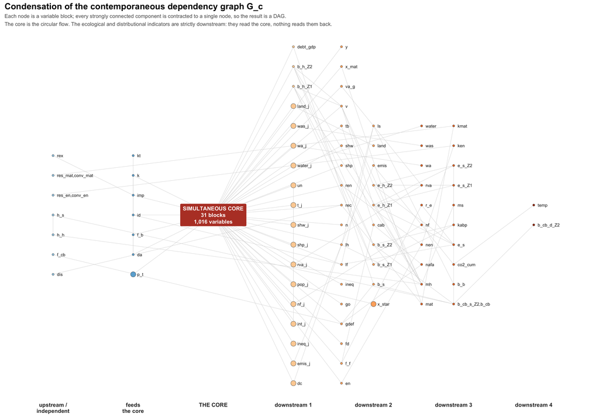

Contracting to variable blocks rather than individual variables gives 116 blocks and 83 components, and the condensation is confirmed acyclic. The core is one node; everything to its right is reachable from it and nothing on that side returns. The layers are the longest-path depth from the core: 36 blocks at depth 1, 20 at depth 2, 10 at depth 3, 2 at depth 4. The ecological cascade runs the full width — sectoral emissions at depth 1, aggregate emissions at depth 2, cumulative CO₂ at depth 3, temperature at depth 4 — and terminates.

Seven blocks sit upstream, feeding the core without receiving from it, of which the substantial one is `p_t`, the target or normal-cost price. Seven more are independent of the core in both directions.

### The effective iteration core is smaller, and the reason is statement order

The gap is **not** elementwise inflation, and it is **not** zeroed coefficients. It is that Gauss–Seidel is sequential within a sweep: a variable assigned early uses the current sweep’s values for everything assigned before it and the previous sweep’s for everything after. So a variable that is assigned *before* any equation reads it never has its incoming value read at all, and is effectively solved out of the iteration.

Measured directly. Perturbing `Z1_x-1`, `Z1_d-1`, `Z1_n_j-1`, `Z1_yd_j-1`, `Z1_ydw_j-1`, `Z1_c` or `Z1_yd` and re-solving changes **zero** variables — at 2, 4, 8, 16 and 32 sweeps alike. The explanation is in the source: `x` is assigned by the Leontief solve at `:205`, and every read of it occurs at a later line (`:208`, `:212`, `:236`, `:471`, `:474`, `:586`, `:626`, `:634`, `:644`–`:646`). By contrast `p` is read at `:212`, `:235` and `:237` — *before* its own assignment at `:584` — and perturbing it reaches 1,910 variables at two sweeps. That is why `p` is in the iteration core and `x` is not.

The consequence is a caution as much as a result: **356 is a property of the source’s statement order, not of the economics.** Reordering the equations would change it while changing nothing about the model. 1,016 is the order-free quantity.

### Switching the disabled behavioural coefficients on changes nothing

The numerical probe runs at the default calibration, in which 48 of the 56 coefficients of the household portfolio matrix Λ are exactly zero. An edge multiplied by zero has zero derivative and disappears from a numerically measured graph, so the core might have been understated for that reason alone. Tested by setting all 48 non-zero — own rate $+0.005$, cross rates $-0.001$, transactions demand $-0.002$, with $\lambda_{22} < \lambda_{20}$ in both regions to respect the known Gauss–Seidel divergence condition — and re-running both probes:

Effect of switching all 48 zeroed portfolio coefficients on.

| Graph | Lambda = 0 | Lambda non-zero |
| --- | --- | --- |
| Contemporaneous core (largest SCC) | 356 | 356 |
| Contemporaneous edges | 607743 | 607744 |
| Lagged variables with any influence | 588 | 588 |
| Lagged edges | 483738 | 483740 |

Zero change to either core; one new contemporaneous edge in 607,743 and two new lagged edges in 483,738. The mechanism behind that null result is the subject of a companion report, `log/report/2026-09-09-portfolio-identification.qmd`, and is not a property of the graph.

## What changed, and a caution about an earlier reading

`R/convergence_profile.R` records the full 130-sweep trajectory at a period and asks, for each variable, when it stops moving. At a relative tolerance of $10^{-10}$, **95.4%** of live variables are still moving at sweep 50 (2,830 of 2,968 at $t = 50$; 2,722 at $t = 80$), and only 4.2% settle after a single sweep.

Read on its own that figure looks like evidence of a very large simultaneous core. **It is not, and treating it as such would have been an error.** A variable that is downstream of the core keeps moving for exactly as long as its inputs keep moving, without participating in any cycle. The settling profile cannot separate “in the core” from “downstream of the core”, and the two graphs built above are what separates them: the core is at most 1,016 and effectively 356, while roughly 2,600 live variables move throughout the solve purely because they are recomputed from a core that has not yet converged.

## What it means

*Interpretation, resting on the measurements above.*

**For the solver.** Gauss–Seidel currently iterates all 6,713 variables 67–99 times per period. Only 356 of them are genuinely carrying the iteration. Converging the core and then evaluating the downstream DAG once, in topological order, is a structural saving of roughly eightfold on the iterated work — distinct from, and composable with, the constant-factor saving available from replacing character row-name matching with integer indexing. Against the decision rule recorded in `ai_context/plans/2026-09-09-dependency-graph-and-flash-mvp.md`, 12.0% falls between the thresholds: both wins are real and neither dominates.

**For forming $M$.** The companion report of the same date establishes $M = (I - J_c)^{-1} J_\ell$ as the linearised one-period transition matrix. Two findings here bear on it. The sparsity pattern of $J_c$ is now known, so structurally orthogonal columns can be perturbed together and $J_c$ formed in a number of solves equal to the chromatic number of the column-intersection graph rather than 6,713. More consequentially, $J_\ell$ has only 588 non-zero *columns*, so $M$ acts non-trivially on a 588-dimensional subspace. A 588 × 588 operator can be formed and diagonalised in full. The leading ten eigenpairs are a conservative target where the entire spectrum is now within reach.

**For the manuscript.** The claim that the ecological and distributional indicators are computed from the circular flow, rather than participating in it, is no longer an interpretive reading of the model — it is a measured property of its dependency graph, and the figure above is the evidence. It answers a referee asking what drives what, and it locates the model precisely with respect to Sraffa’s basics and non-basics: the basics here are the 1,016 variables of the circular flow, and emissions, land, water, inequality and temperature are non-basic in exactly Sraffa’s sense — they can be deleted without disturbing the determination of anything else.

That last point cuts both ways and should be stated plainly rather than presented as a virtue. A model in which emissions never feed back into production or prices cannot represent ecological damage constraining accumulation. Whether that is an acceptable simplification or a limitation worth addressing is a modelling judgement, not something this measurement settles — but it is now a documented property rather than an implicit one.

## Limits and what is not established

- **1,016 is an upper bound and 356 a lower bound on different quantities, not on one.** 1,016 bounds the structural core from above because the parse records elementwise operations as dense. 356 bounds the effective iteration core from below because a perturbation to a variable reassigned early in the sweep cannot be seen. The true structural core lies between 356 and 1,016 and this report does not pin it down. Resolving it would require determining, per assignment, whether each source block enters elementwise or densely — mechanical for the four regular shapes, a judgement for the ~103 composed forms.
- **356 is measured at one point on one baseline path**, at $t = 50$, on the unshocked baseline. It is a property of statement order and would change under reordering without any economic change.
- **The parse is a superset over branches.** All ten `if` bodies are taken and all four loops unrolled, so $G_c$ contains edges that are live on no single run. The numerical probe establishes which are live on the baseline path; the two together bracket rather than determine.
- ⚠️ **UNCERTAIN: the parse has not been validated edge-by-edge.** The intended check — perturb a sample of variables and confirm the set that moves is contained in the parsed out-neighbourhood — was superseded by the discovery that perturbation cannot see past an early reassignment, which makes containment untestable for exactly the variables where it matters. The parse’s correctness rests instead on its handling of the two unresolved expressions being benign (verified: both are the `return()` at `:881`) and on its core composition being economically coherent (it is). A stronger check would be to compare against an independent implementation.
- **The lagged graph was measured only at the default parameter point and one perturbed one.** 588 is the count of lagged variables with non-zero influence at those two points, not a structural count of lagged reads; the parse’s corresponding figure is 804 live variables with non-zero lagged out-degree.

## Where this leaves things

`ai_context/` records none of this. It has no dependency structure for the equation block, and its account of the model’s cost is superseded on a separate point already. `/update-project-context` is warranted.

Three things this makes possible, offered as options rather than as a sequence:

1. **Restructure the solver around the 356-variable core**, evaluating the downstream DAG once in the topological order the condensation supplies. The saving is on the iterated work, and it composes with the integer-indexing rewrite rather than competing with it.
2. **Form $M$ explicitly on its 588-dimensional active subspace** and take the whole spectrum, rather than the leading eigenpairs by Krylov iteration. This is now the cheaper route, not the more expensive one.
3. **Put the condensation figure in the supplementary material.** Insufficient model documentation is the first-stated complaint of both referee reports on ECOLEC-D-26-01324, and a measured statement of what determines what is a direct answer to it.

**Sources:** `model/MVP_model_2026.R` · `model/run_model_2026.R:158–245` · `model/demand_scenarios_2026.R:55–150` · `utils/aux_utils.R:11–38` · `R/dependency_graph.R`, `R/scc_lower_bound.R`, `R/convergence_profile.R`, `R/scc_lambda_on.R`, `R/lagged_graph_lambda.R` · `data/dependency_graph.rds`, `data/scc_lower_bound.rds`, `data/lagged_graph_lambda.rds` · `output/scenarios/full_mrio_baseline_2026.RDS` · commit `0c43cdf` · companion reports `log/report/2026-09-09-dynamical-form.qmd` and `log/report/2026-09-09-portfolio-identification.qmd` · plan `ai_context/plans/2026-09-09-dependency-graph-and-flash-mvp.md` · Sraffa, *Production of Commodities by Means of Commodities* (1960), §§6–7 on basics and non-basics.